# “Data Analysis in R Part 3: Data Modeling and Machine Learning”

Stephen Guest

November 8, 2016

First things first, let’s load in the caret library so that it will be available for us to use.

```r
library(caret)
set.seed(1364)
```

Now we’ll load in the Alzheimers data set that we’ve been working with in previous sessions.

```r
Alz <- read.csv(file.choose())
dim(Alz)
```

```
## [1] 333 132
```

```r
summary(Alz$gender)
```

```
## female Female      M   male   Male
##      2    202      3      2    124
```

Before we go on let’s clean up one of our variables that has some inconsistencies

```r
Alz$gender <- ifelse(Alz$gender == 'female', 'Female', ifelse(Alz$gender == 'M', 'Male', ifelse(Alz$gender == 'male', 'Male', ifelse(Alz$gender == 'Female', 'Female', 'Male'))))
Alz$gender <- as.factor(Alz$gender)
```

**Partitioning Data Into Training and Test Sets** Typically one of the first things we want to do before building any prediction model is to take our data and split it up into a ‘training’ set that will be used to teach the model and a ‘test’ set that will be used as part of validating the model

The caret package has some really simple built in functions for partitioning data. Let’s use **createDataPartition()** to split the Alzheimers data set into a train and test set

```r
samples_for_training <- createDataPartition(Alz$response, p=.75, list=F)
training_samples <- Alz[samples_for_training,]
test_samples <- Alz[-samples_for_training,]
```

**Ready to Build a Model** We’re now ready to build a model using any of the machine learning algorithms that are built into caret

There are >200 machine learning algorithms available in the caret package

Whichever algorithm we choose we can generate a model using **train()** function

```r
my_model_gbm <- train(response ~ ., data = training_samples, method = "gbm")
```

That’s it.  
We’ve got a model now that we can use to make predictions.

Taking a look at the model we built

```r
my_model_gbm
```

```
## Stochastic Gradient Boosting
##
## 251 samples
## 131 predictors
##   2 classes: 'Impaired', 'NotImpaired'
##
## No pre-processing
## Resampling: Bootstrapped (25 reps)
## Summary of sample sizes: 251, 251, 251, 251, 251, 251, ...
## Resampling results across tuning parameters:
##
##   interaction.depth  n.trees  Accuracy   Kappa
##   1                   50      0.8016530  0.4285405
##   1                  100      0.8240044  0.5103785
##   1                  150      0.8240777  0.5195473
##   2                   50      0.8192888  0.4959376
##   2                  100      0.8268481  0.5236718
##   2                  150      0.8247815  0.5228646
##   3                   50      0.8286565  0.5213867
##   3                  100      0.8230417  0.5122095
##   3                  150      0.8240807  0.5197905
##
## Tuning parameter 'shrinkage' was held constant at a value of 0.1
##
## Tuning parameter 'n.minobsinnode' was held constant at a value of 10
## Accuracy was used to select the optimal model using  the largest value.
## The final values used for the model were n.trees = 50, interaction.depth
##  = 3, shrinkage = 0.1 and n.minobsinnode = 10.
```

**Generating Predictions with our model** Let’s make some predictions using the test data set and see how the model performs

To generate predictions we use the **predict()** function

```r
my_gbm_predictions <- predict(my_model_gbm, newdata = test_samples)
```

**Model Performance** Visualizing model performance with a confusion matrix!

```r
cMatrix_gbm <- confusionMatrix(my_gbm_predictions, test_samples$response)
cMatrix_gbm
```

```
## $positive
## [1] "Impaired"
##
## $table
##              Reference
## Prediction    Impaired NotImpaired
##   Impaired          13           1
##   NotImpaired        9          59
##
## $overall
##       Accuracy          Kappa  AccuracyLower  AccuracyUpper   AccuracyNull
##    0.878048780    0.648972603    0.787141173    0.939941987    0.731707317
## AccuracyPValue  McnemarPValue
##    0.001090334    0.026856696
##
## $byClass
##          Sensitivity          Specificity       Pos Pred Value
##            0.5909091            0.9833333            0.9285714
##       Neg Pred Value            Precision               Recall
##            0.8676471            0.9285714            0.5909091
##                   F1           Prevalence       Detection Rate
##            0.7222222            0.2682927            0.1585366
## Detection Prevalence    Balanced Accuracy
##            0.1707317            0.7871212
##
## $mode
## [1] "sens_spec"
##
## $dots
## list()
##
## attr(,"class")
## [1] "confusionMatrix"
```

**Switching Algorithms** Caret makes it exceptionally easy to try a different algorithm

```r
my_model_glm <- train(response ~ ., data = training_samples, method = "glm")
my_glm_predictions <- predict(my_model_glm, newdata = test_samples)
cMatrix_glm <- confusionMatrix(my_glm_predictions, test_samples$response)
cMatrix_glm
```

```
## $positive
## [1] "Impaired"
##
## $table
##              Reference
## Prediction    Impaired NotImpaired
##   Impaired          17          17
##   NotImpaired        5          43
##
## $overall
##       Accuracy          Kappa  AccuracyLower  AccuracyUpper   AccuracyNull
##     0.73170732     0.41731266     0.62244024     0.82361014     0.73170732
## AccuracyPValue  McnemarPValue
##     0.55706563     0.01901647
##
## $byClass
##          Sensitivity          Specificity       Pos Pred Value
##            0.7727273            0.7166667            0.5000000
##       Neg Pred Value            Precision               Recall
##            0.8958333            0.5000000            0.7727273
##                   F1           Prevalence       Detection Rate
##            0.6071429            0.2682927            0.2073171
## Detection Prevalence    Balanced Accuracy
##            0.4146341            0.7446970
##
## $mode
## [1] "sens_spec"
##
## $dots
## list()
##
## attr(,"class")
## [1] "confusionMatrix"
```

**compare the two models**

```r
cMatrix_gbm$overall[1]
```

```
##  Accuracy
## 0.8780488
```

```r
cMatrix_glm$overall[1]
```

```
##  Accuracy
## 0.7317073
```

**Imporoving our models** For some algorithms to run or be optimized we might need to preprocess data

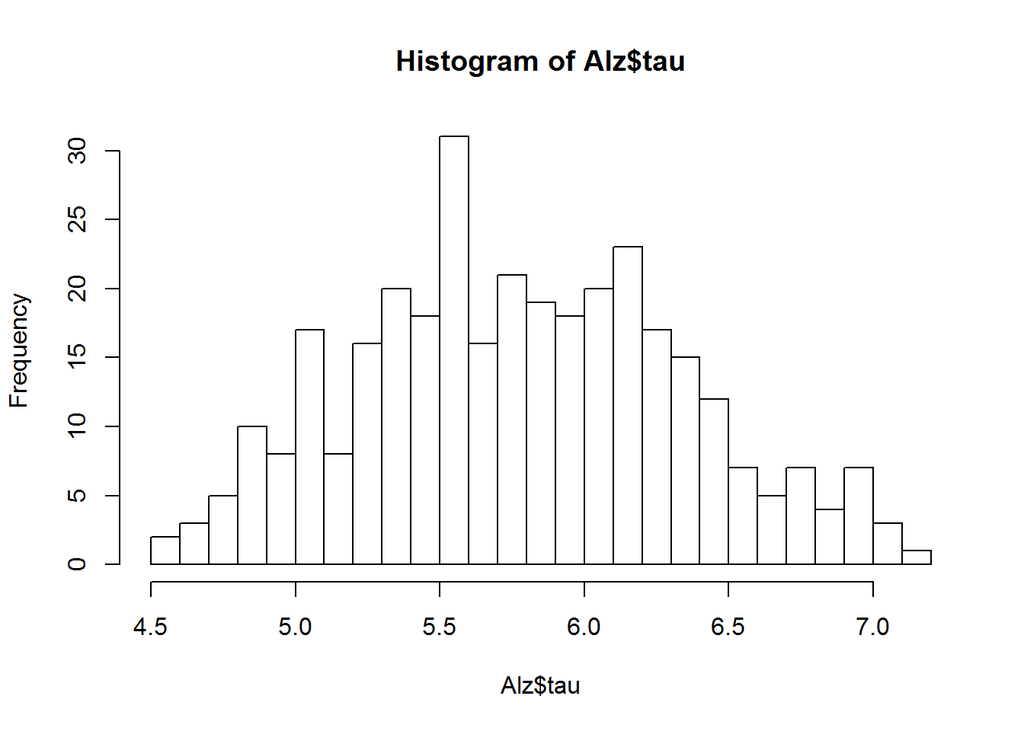

```r
hist(Alz$tau, breaks = 30)
```

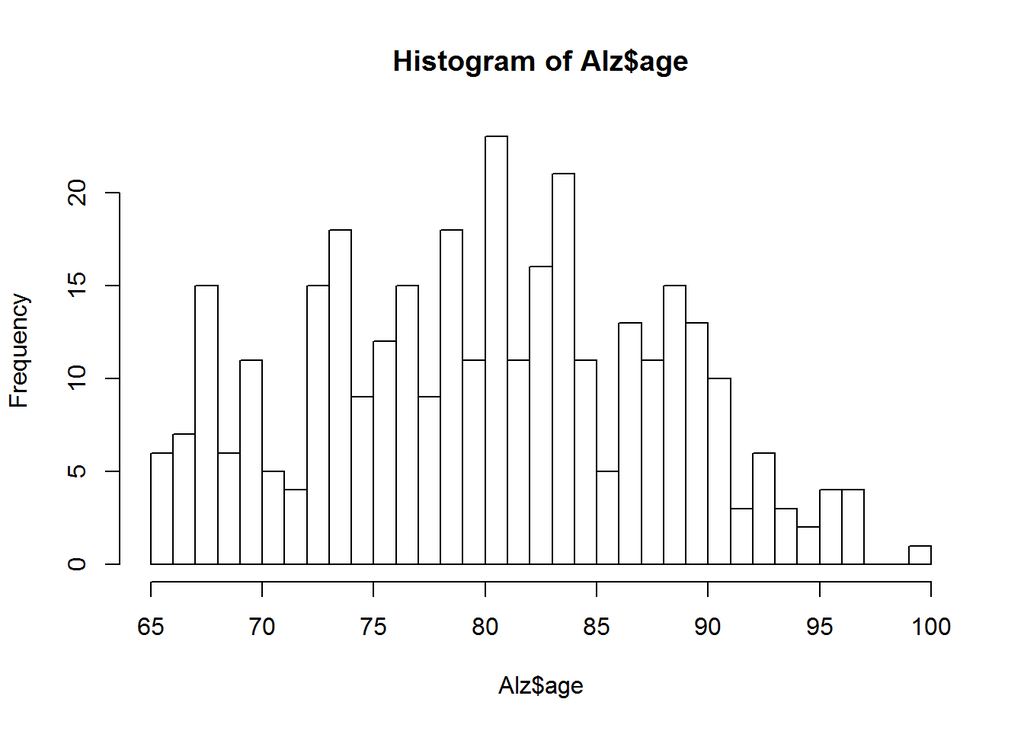

```r
hist(Alz$age, breaks = 30)
```

**Scaling Data** Using the **scale()** function we can get all of our variables to have a mean of 0 and standard deviation of 1.

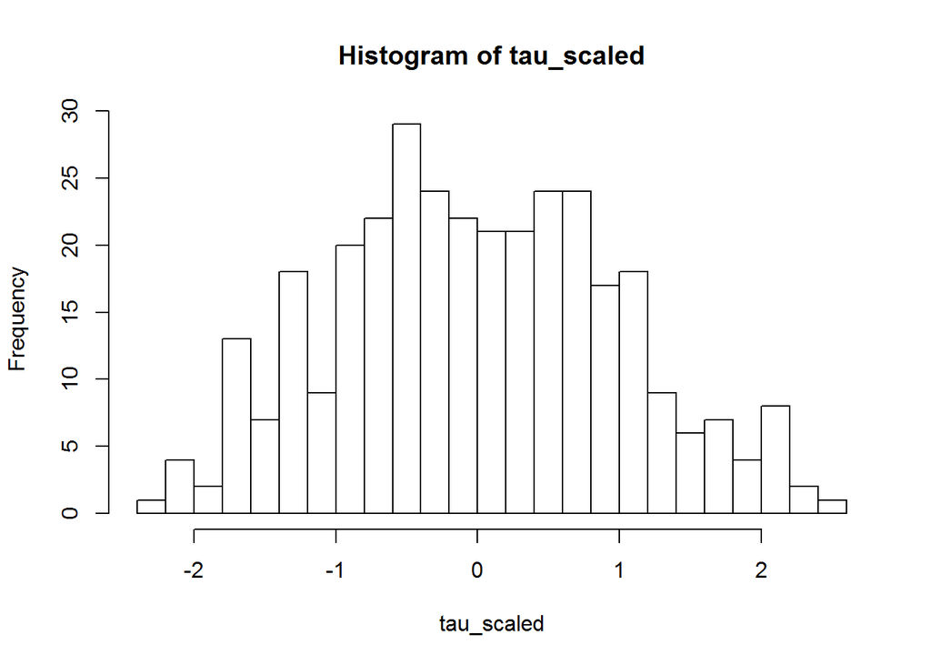

```r
tau_scaled <- scale(Alz$tau, center = TRUE)
age_scaled <- scale(Alz$age, center = TRUE)
hist(tau_scaled, breaks = 30)
```

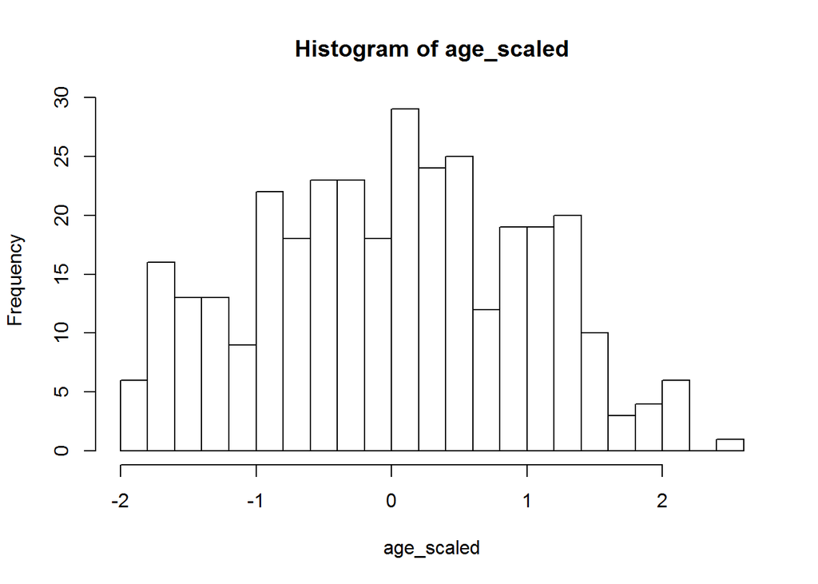

```r
hist(age_scaled, breaks = 30)
```

**Dummy variables** Some machine learning algorithms can’t handle factor variables. They must be turned into numeric type data. This process is referred to as creating dummy variables

So which of our variables are factor variables?

```r
Alz_var_classes <- sapply(Alz, class)
which(Alz_var_classes == 'factor')
```

```
## Genotype response   gender
##      130      131      132
```

Genotype, response and gender are all factor variables.

Let’s see how we can turn one of them into a dummy variable using **dummyVars()** in caret

```r
dmy <- dummyVars(~ Genotype, data = Alz)
dmy_df <- data.frame(predict(dmy, newdata = Alz))
head(dmy_df)
```

```
##   Genotype.E2E2 Genotype.E2E3 Genotype.E2E4 Genotype.E3E3 Genotype.E3E4
## 1             0             0             0             1             0
## 2             0             0             0             0             1
## 3             0             0             0             0             1
## 4             0             0             0             0             1
## 5             0             0             0             1             0
## 6             0             0             0             0             0
##   Genotype.E4E4
## 1             0
## 2             0
## 3             0
## 4             0
## 5             0
## 6             1
```

```r
head(Alz$Genotype)
```

```
## [1] E3E3 E3E4 E3E4 E3E4 E3E3 E4E4
## Levels: E2E2 E2E3 E2E4 E3E3 E3E4 E4E4
```